# Chapter 01, Week 03, Problem Set Key

Week 03 Problem Answers

### 1.9

```r
pop <- c(3278, 3347, 3417, 3486, 3558, 3632, 3708, 3785, 3861, 3936, 4011, 4084, 4156, 4226, 4298, 4372, 4447, 4522, 4601, 4682, 4762, 4844, 4927, 5013, 5099, 5185, 5273, 5357, 5440, 5521, 5601, 5681, 5762, 5840, 5918, 5995, 6072, 6147, 6222, 6297, 6373, 6449)
years <- seq(from = 1964, to = 2005, by = 1)
```

Estimate the intrinsic rate of increase (or decrease) for each successive year, and plot the estimated intrinsic rate versus the population density. Is it a float, straits line, as would be expected if the population were growing exponentially? What kind of function would describe the data relatively well?

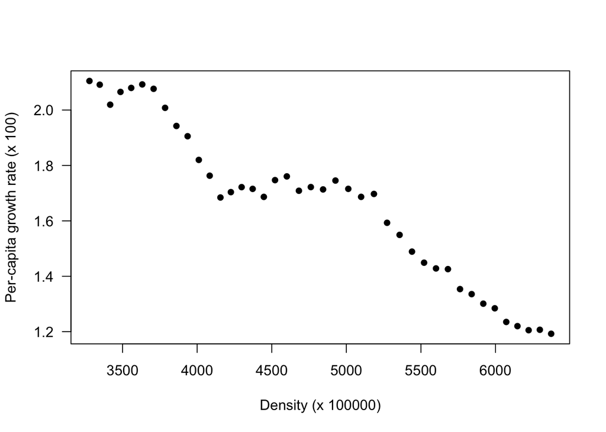

```r
n.years <- length(years)
popt <- pop[-n.years]
popt1 <- pop[-1]
diff.pop <- popt1 - popt
pcgr <- diff.pop/popt # pcgr = per-capita growth
plot(x = popt, y = pcgr*100, xlab = "Density (x 100000)", ylab = "Per-capita growth rate (x 100)", las = 1, pch = 16)
```

The function is generally decreasing. If I knew nothing about population change or population size, I’d posit that it is generatlly a negatively linear relationship.

### 1.10

Graphically estimate the point at which the population population will stop growing (the number of individuals in the word at the point at which the observed trend will reach 0). How would various sections of the data, if considered alone, change your conclusions?

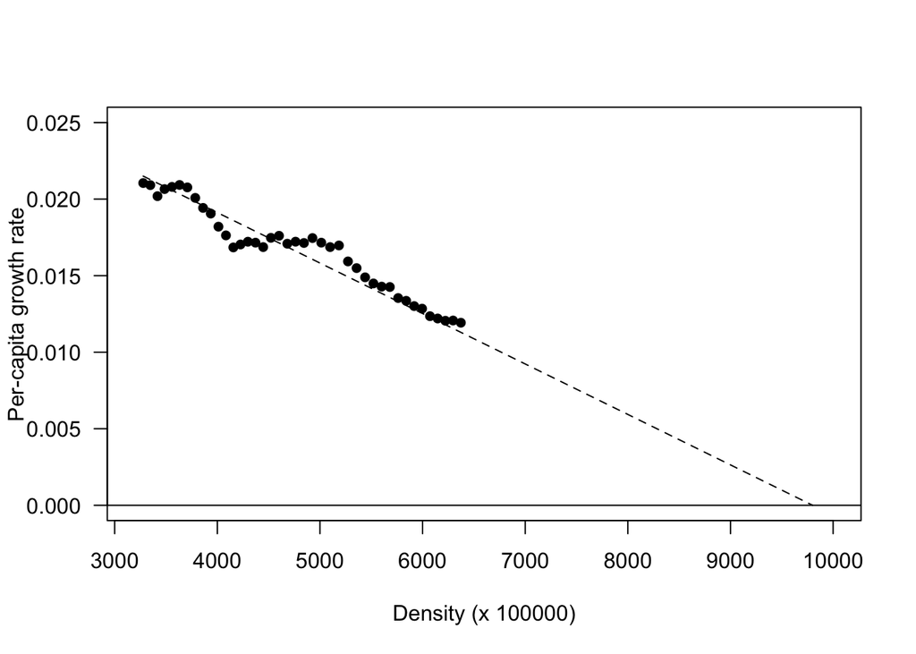

```r
plot(x = popt, y = pcgr, xlab = "Density (x 100000)", ylab = "Per-capita growth rate", las = 1, pch = 16, ylim = c(0, 0.025), xlim = c(3200, 10000))
segments(x0 = 2500, y0 = 0, x1 = 15000, y1 = 0)
segments(x0 = 3278, y0 = 0.0215, x1 = 9800, y1 = 0, lty = 2)
```

### 1.11

Using the UN data on the human population, insert the linear approximation of the intrinsic rate of increase as it relates to population density, and graphically estimate the value of the intrinsic rate of increase (the limiting value as density approaches zero).

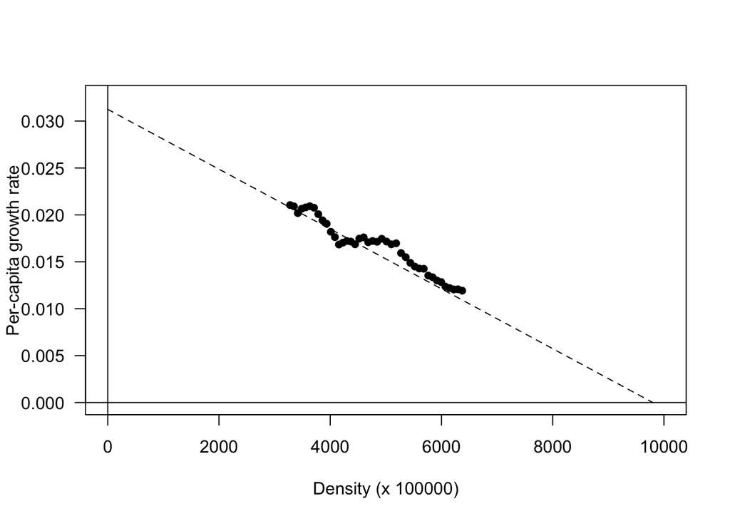

```r
plot(x = popt, y = pcgr, xlab = "Density (x 100000)", ylab = "Per-capita growth rate", las = 1, pch = 16, ylim = c(0, 0.0325), xlim = c(0, 10000))
segments(x0 = -500, y0 = 0, x1 = 15000, y1 = 0)
segments(x0 = 0, y0 = -1, x1 = 0, y1 = 1)
segments(x0 = 0, y0 = 0.03125, x1 = 9800, y1 = 0, lty = 2)
```

My visual estimate is that the per-capita growth rate when density is equal to 0 is approximately 0.03125. The estimate describes the per-capita growth rate when there is no effect of density. In other words, it is the estimate of the growth rate that is density indepdent.

### 1.12

Beginning with the exponential equation, assume that the rate of change decreases linearly with population density (i.e., substitute $a - bN$ for $r$). Show what substitutions you need to make to write the equation in its more biologically sensible form (i.e., with the intrinsic rate of natural incrase and the carrying capacity evident). How do $a$ and $b$ of the linear approximation relate to the $r$ and $K$ of $\frac{\mathrm{d}N}{\mathrm{d}t} = rN\left(\frac{K-N}{K}\right)$?

The exponential eqaution is $\frac{dN}{dt} = rN$, and replacing $r$ with $a - bN$ gives us $\frac{dN}{dt} = N\left(a - bN\right)$. In this case, as the rate of change decreases linearly with population density, like 1.11, $a$ would be the per-capita growth rate when density is near 0 and $b$ would be the negative linear relationship between density and per-capita growth rate.

### 1.16

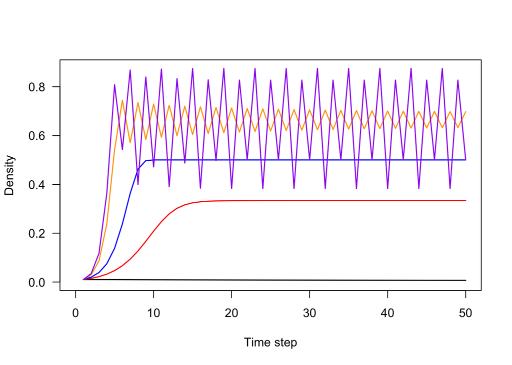

```r
N0_1.16 <- 0.01
lambda.vec <- c(1, 1.5, 2, 3, 3.5)
n.lambdas <- length(lambda.vec)
n.steps_1.16 <- 50
vec.steps_1.16 <- 1:n.steps_1.16
N.mat <- matrix(data = NA, nrow = n.lambdas, ncol = n.steps_1.16) # each row will be a
N.mat[,1] <- N0_1.16 # it fills the entire column with initial N0

for (i in 1:n.lambdas) {
  for (j in 2:n.steps_1.16) {
    N.mat[i, j] <- lambda.vec[i]*N.mat[i, j-1]*(1 - N.mat[i, j-1])
  }
}

plot(NA, type = "n", xlim = c(0, n.steps_1.16), ylim = c(0, max(N.mat)), xlab = "Time step", ylab = "Density", las = 1)
  lines(x = vec.steps_1.16, y = N.mat[1,] , lwd = 1.5) # lwd is the "line width"
  lines(x = vec.steps_1.16, y = N.mat[2,] , lwd = 1.5, col = "red")
  lines(x = vec.steps_1.16, y = N.mat[3,] , lwd = 1.5, col = "blue")
  lines(x = vec.steps_1.16, y = N.mat[4,] , lwd = 1.5, col = "orange")
  lines(x = vec.steps_1.16, y = N.mat[5,] , lwd = 1.5, col = "purple")
```

The time series change by first increasing more rapidly with increasing $\lambda$, as you can see in the first few time steps. For the larger values of $\lambda$, the time series begin to fluctuate.

Viewed as density at time $t$ against density at time $t+1$, it’d look like:

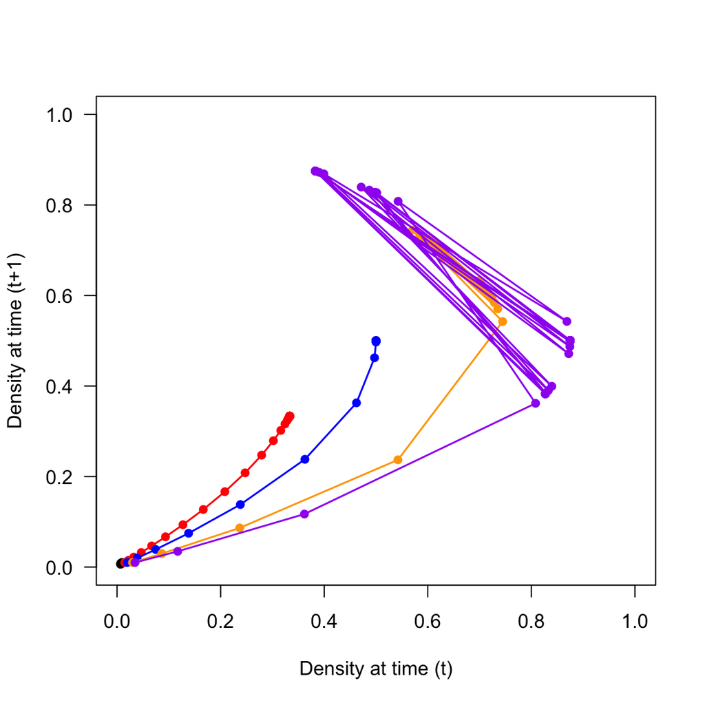

```r
N0_1.16 <- 0.01
lambda.vec <- c(1, 1.5, 2, 3, 3.5)
n.lambdas <- length(lambda.vec)
n.steps_1.16 <- 50
vec.steps_1.16 <- 1:n.steps_1.16
N.mat <- matrix(data = NA, nrow = n.lambdas, ncol = n.steps_1.16) # each row will be a
N.mat[,1] <- N0_1.16 # it fills the entire column with initial N0

for (i in 1:n.lambdas) {
  for (j in 2:n.steps_1.16) {
    N.mat[i, j] <- lambda.vec[i]*N.mat[i, j-1]*(1 - N.mat[i, j-1])
  }
}

plot(NA, type = "n", xlim = c(0, 1), ylim = c(0, 1), xlab = "Density at time (t)", ylab = "Density at time (t+1)", las = 1)
  lines(x = N.mat[1,-1], y = N.mat[1,-n.steps_1.16], lwd = 1.5) # lwd is the "line width"
  points(x = N.mat[1,-1], y = N.mat[1,-n.steps_1.16], pch = 16)
  lines(x = N.mat[2,-1], y = N.mat[2,-n.steps_1.16], lwd = 1.5, col = "red")
  points(x = N.mat[2,-1], y = N.mat[2,-n.steps_1.16], pch = 16, col = "red")
  lines(x = N.mat[3,-1], y = N.mat[3,-n.steps_1.16], lwd = 1.5, col = "blue")
  points(x = N.mat[3,-1], y = N.mat[3,-n.steps_1.16], pch = 16, col = "blue")
  lines(x = N.mat[4,-1], y = N.mat[4,-n.steps_1.16], lwd = 1.5, col = "orange")
  points(x = N.mat[4,-1], y = N.mat[4,-n.steps_1.16], pch = 16, col = "orange")
  lines(x = N.mat[5,-1], y = N.mat[5,-n.steps_1.16], lwd = 1.5, col = "purple")
  points(x = N.mat[5,-1], y = N.mat[5,-n.steps_1.16], pch = 16, col = "purple")
```

### 1.18

Plot $N_{t+1}$ against $N_t$ for the Beverton and Holt model, the Hassell model, and the Ricker model (eqns. 28–30), and compare them. Let $\lambda = 1$, $\alpha = 1$, and $b = 2$. Once you get the three models on a spreadsheet, experiment with different values of $b$, $\lambda$, and $\alpha$.

As a time series (not asked for, but FYI):

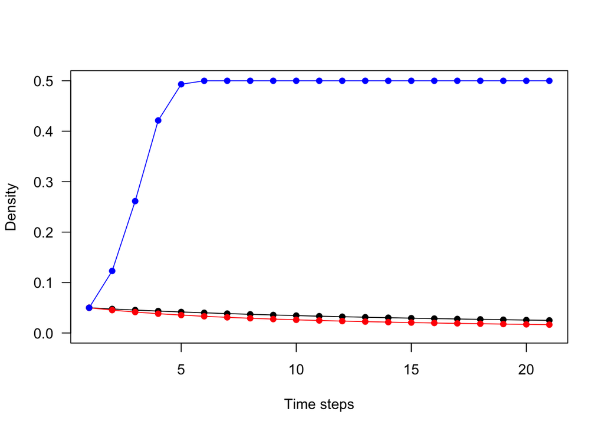

```r
steps <- 21
N_BH <- vector(length = steps, mode = "numeric")
N_H <- vector(length = steps, mode = "numeric")
N_R <- vector(length = steps, mode = "numeric")
N_BH[1] <- 0.05
N_H[1] <- 0.05
N_R[1] <- 0.05
for (i in 2:steps) {
  N_BH[i] <- (1*N_BH[i-1]) / (1 + 1*N_BH[i-1])
  N_H[i] <- (1*N_H[i-1]) / ((1 + 1*N_H[i-1])^2)
  N_R[i] <- N_R[i-1]*exp(1*(1 - 2*N_R[i-1]))
}
plot(x = 1:steps, y = N_BH, las = 1, xlab = "Time steps", ylab = "Density", ylim = c(0, 0.5), pch = 16)
  lines(x = 1:steps, y = N_BH, col = "black", pch = 16)
points(x = 1:steps, y = N_H, col = "red", pch = 16)
  lines(x = 1:steps, y = N_H, col = "red")
points(x = 1:steps, y = N_R, col = "blue", pch = 16)
  lines(x = 1:steps, y = N_R, col = "blue")
```

As density at $t$ against density at $t+1$:

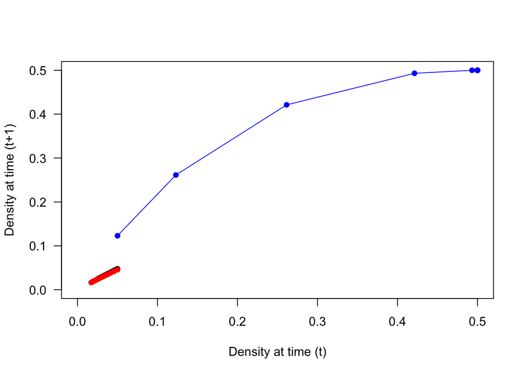

```r
plot(x = N_BH[-steps], y = N_BH[-1], las = 1, xlab = "Density at time (t)", ylab = "Density at time (t+1)", xlim = c(0, 0.5), ylim = c(0, 0.5), pch = 16)
  lines(x = N_BH[-steps], y = N_BH[-1], col = "black", pch = 16)
points(x = N_H[-steps], y = N_H[-1], col = "red", pch = 16)
  lines(x = N_H[-steps], y = N_H[-1], col = "red")
points(x = N_R[-steps], y = N_R[-1], col = "blue", pch = 16)
  lines(x = N_R[-steps], y = N_R[-1], col = "blue")
```